# ISIS 4219 - Machine Learning Techniques

Overview

Dataset info

| Number of variables | 45 |
| --- | --- |
| Number of observations | 82332 |
| Total Missing (%) | 0.0% |
| Total size in memory | 28.3 MiB |
| Average record size in memory | 360.0 B |

Variables types

| Numeric | 27 |
| --- | --- |
| Categorical | 4 |
| Boolean | 1 |
| Date | 0 |
| Text (Unique) | 0 |
| Rejected | 13 |
| Unsupported | 0 |

Warnings

- `ackdat` has 41160 / 50.0% zeros Zeros

- `ct_dst_sport_ltm` is highly correlated with `ct_src_dport_ltm` (ρ = 0.91164) Rejected

- `ct_dst_src_ltm` is highly correlated with `ct_srv_src` (ρ = 0.9338) Rejected

- `ct_flw_http_mthd` has 74752 / 90.8% zeros Zeros

- `ct_ftp_cmd` is highly correlated with `is_ftp_login` (ρ = 0.99434) Rejected

- `ct_src_dport_ltm` is highly correlated with `ct_dst_ltm` (ρ = 0.9604) Rejected

- `ct_src_ltm` is highly correlated with `ct_src_dport_ltm` (ρ = 0.93317) Rejected

- `ct_srv_dst` is highly correlated with `ct_dst_src_ltm` (ρ = 0.94105) Rejected

- `ct_state_ttl` has 17045 / 20.7% zeros Zeros

- `dbytes` is highly correlated with `dpkts` (ρ = 0.97642) Rejected

- `dinpkt` is highly skewed (γ1 = 23.013) Skewed

- `dinpkt` has 36015 / 43.7% zeros Zeros

- `djit` is highly skewed (γ1 = 60.562) Skewed

- `djit` has 41552 / 50.5% zeros Zeros

- `dload` has 36013 / 43.7% zeros Zeros

- `dloss` is highly correlated with `dbytes` (ρ = 0.99711) Rejected

- `dmean` has 36006 / 43.7% zeros Zeros

- `dpkts` is highly skewed (γ1 = 49.304) Skewed

- `dpkts` has 36006 / 43.7% zeros Zeros

- `dtcpb` has 40894 / 49.7% zeros Zeros

- `dttl` has 36067 / 43.8% zeros Zeros

- `dur` has 950 / 1.2% zeros Zeros

- `dwin` is highly correlated with `swin` (ρ = 0.96012) Rejected

- `is_ftp_login` has 81654 / 99.2% zeros Zeros

- `is_sm_ips_ports` is highly correlated with `sinpkt` (ρ = 0.94451) Rejected

- `proto` has a high cardinality: 131 distinct values Warning

- `rate` has 999 / 1.2% zeros Zeros

- `response_body_len` is highly skewed (γ1 = 74.635) Skewed

- `response_body_len` has 76675 / 93.1% zeros Zeros

- `sbytes` is highly correlated with `spkts` (ρ = 0.96575) Rejected

- `sjit` has 38650 / 46.9% zeros Zeros

- `sload` has 999 / 1.2% zeros Zeros

- `sloss` is highly correlated with `sbytes` (ρ = 0.99503) Rejected

- `spkts` is highly skewed (γ1 = 47.748) Skewed

- `stcpb` has 40881 / 49.7% zeros Zeros

- `sttl` has 1048 / 1.3% zeros Zeros

- `swin` has 39237 / 47.7% zeros Zeros

- `synack` is highly correlated with `tcprtt` (ρ = 0.93947) Rejected

- `tcprtt` has 41127 / 50.0% zeros Zeros

- `trans_depth` is highly skewed (γ1 = 170.79) Skewed

- `trans_depth` has 74750 / 90.8% zeros Zeros

Variables

ackdat  
Numeric

| Distinct count | 24020 |
| --- | --- |
| Unique (%) | 29.2% |
| Missing (%) | 0.0% |
| Missing (n) | 0 |
| Infinite (%) | 0.0% |
| Infinite (n) | 0 |

| Mean | 0.026669 |
| --- | --- |
| Minimum | 0 |
| Maximum | 2.9288 |
| Zeros (%) | 50.0% |

Toggle details

**Statistics**

Quantile statistics

| Minimum | 0 |
| --- | --- |
| 5-th percentile | 0 |
| Q1 | 0 |
| Median | 8e-05 |
| Q3 | 0.048816 |
| 95-th percentile | 0.10489 |
| Maximum | 2.9288 |
| Range | 2.9288 |
| Interquartile range | 0.048816 |

Descriptive statistics

| Standard deviation | 0.055094 |
| --- | --- |
| Coef of variation | 2.0658 |
| Kurtosis | 235.31 |
| Mean | 0.026669 |
| MAD | 0.034747 |
| Skewness | 9.6287 |
| Sum | 2195.7 |
| Variance | 0.0030353 |
| Memory size | 643.3 KiB |

**Histogram**

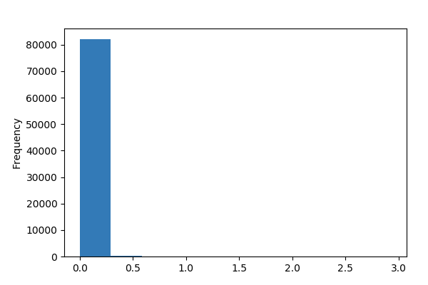

**Common Values**

| Value | Count | Frequency (%) |  |
| --- | --- | --- | --- |
| 0.0 | 41160 | 50.0% |  |
| 0.000134 | 487 | 0.6% |  |
| 0.000133 | 471 | 0.6% |  |
| 0.000135 | 462 | 0.6% |  |
| 0.000136 | 398 | 0.5% |  |
| 0.000132 | 384 | 0.5% |  |
| 0.000123 | 342 | 0.4% |  |
| 0.00013700000000000002 | 331 | 0.4% |  |
| 0.000131 | 317 | 0.4% |  |
| 0.000122 | 305 | 0.4% |  |
| Other values (24010) | 37675 | 45.8% |  |

**Extreme Values**

Minimum 5 values

| Value | Count | Frequency (%) |  |
| --- | --- | --- | --- |
| 0.0 | 41160 | 50.0% |  |
| 7.3e-05 | 1 | 0.0% |  |
| 7.7e-05 | 2 | 0.0% |  |
| 7.8e-05 | 1 | 0.0% |  |
| 7.900000000000001e-05 | 1 | 0.0% |  |

Maximum 5 values

| Value | Count | Frequency (%) |  |
| --- | --- | --- | --- |
| 1.476815 | 1 | 0.0% |  |
| 1.581634 | 1 | 0.0% |  |
| 1.75063 | 1 | 0.0% |  |
| 1.876614 | 1 | 0.0% |  |
| 2.928778 | 1 | 0.0% |  |

attack_cat  
Categorical

| Distinct count | 10 |
| --- | --- |
| Unique (%) | 0.0% |
| Missing (%) | 0.0% |
| Missing (n) | 0 |

| Normal | 37000 |
| --- | --- |
| Generic | 18871 |
| Exploits | 11132 |
| Other values (7) | 15329 |

Toggle details

| Value | Count | Frequency (%) |  |
| --- | --- | --- | --- |
| Normal | 37000 | 44.9% |  |
| Generic | 18871 | 22.9% |  |
| Exploits | 11132 | 13.5% |  |
| Fuzzers | 6062 | 7.4% |  |
| DoS | 4089 | 5.0% |  |
| Reconnaissance | 3496 | 4.2% |  |
| Analysis | 677 | 0.8% |  |
| Backdoor | 583 | 0.7% |  |
| Shellcode | 378 | 0.5% |  |
| Worms | 44 | 0.1% |  |

ct_dst_ltm  
Numeric

| Distinct count | 50 |
| --- | --- |
| Unique (%) | 0.1% |
| Missing (%) | 0.0% |
| Missing (n) | 0 |
| Infinite (%) | 0.0% |
| Infinite (n) | 0 |

| Mean | 5.7449 |
| --- | --- |
| Minimum | 1 |
| Maximum | 59 |
| Zeros (%) | 0.0% |

Toggle details

**Statistics**

Quantile statistics

| Minimum | 1 |
| --- | --- |
| 5-th percentile | 1 |
| Q1 | 1 |
| Median | 2 |
| Q3 | 6 |
| 95-th percentile | 25 |
| Maximum | 59 |
| Range | 58 |
| Interquartile range | 5 |

Descriptive statistics

| Standard deviation | 8.4181 |
| --- | --- |
| Coef of variation | 1.4653 |
| Kurtosis | 7.1349 |
| Mean | 5.7449 |
| MAD | 5.475 |
| Skewness | 2.667 |
| Sum | 472991 |
| Variance | 70.865 |
| Memory size | 643.3 KiB |

**Histogram**

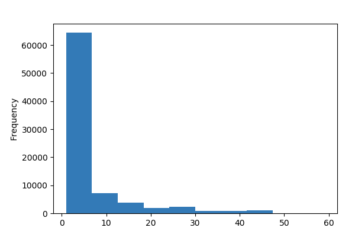

**Common Values**

| Value | Count | Frequency (%) |  |
| --- | --- | --- | --- |
| 1 | 27088 | 32.9% |  |
| 2 | 15309 | 18.6% |  |
| 3 | 9010 | 10.9% |  |
| 4 | 7122 | 8.7% |  |
| 5 | 3172 | 3.9% |  |
| 7 | 3171 | 3.9% |  |
| 6 | 2712 | 3.3% |  |
| 18 | 1552 | 1.9% |  |
| 25 | 1489 | 1.8% |  |
| 8 | 1278 | 1.6% |  |
| Other values (40) | 10429 | 12.7% |  |

**Extreme Values**

Minimum 5 values

| Value | Count | Frequency (%) |  |
| --- | --- | --- | --- |
| 1 | 27088 | 32.9% |  |
| 2 | 15309 | 18.6% |  |
| 3 | 9010 | 10.9% |  |
| 4 | 7122 | 8.7% |  |
| 5 | 3172 | 3.9% |  |

Maximum 5 values

| Value | Count | Frequency (%) |  |
| --- | --- | --- | --- |
| 47 | 10 | 0.0% |  |
| 48 | 7 | 0.0% |  |
| 50 | 1 | 0.0% |  |
| 52 | 5 | 0.0% |  |
| 59 | 10 | 0.0% |  |

ct_dst_sport_ltm  
Highly correlated

*This variable is highly correlated with `ct_src_dport_ltm` and should be ignored for analysis*

| Correlation | 0.91164 |
| --- | --- |

ct_dst_src_ltm  
Highly correlated

*This variable is highly correlated with `ct_srv_src` and should be ignored for analysis*

| Correlation | 0.9338 |
| --- | --- |

ct_flw_http_mthd  
Numeric

| Distinct count | 8 |
| --- | --- |
| Unique (%) | 0.0% |
| Missing (%) | 0.0% |
| Missing (n) | 0 |
| Infinite (%) | 0.0% |
| Infinite (n) | 0 |

| Mean | 0.12974 |
| --- | --- |
| Minimum | 0 |
| Maximum | 16 |
| Zeros (%) | 90.8% |

Toggle details

**Statistics**

Quantile statistics

| Minimum | 0 |
| --- | --- |
| 5-th percentile | 0 |
| Q1 | 0 |
| Median | 0 |
| Q3 | 0 |
| 95-th percentile | 1 |
| Maximum | 16 |
| Range | 16 |
| Interquartile range | 0 |

Descriptive statistics

| Standard deviation | 0.63868 |
| --- | --- |
| Coef of variation | 4.9227 |
| Kurtosis | 228.18 |
| Mean | 0.12974 |
| MAD | 0.2356 |
| Skewness | 12.558 |
| Sum | 10682 |
| Variance | 0.40792 |
| Memory size | 643.3 KiB |

**Histogram**

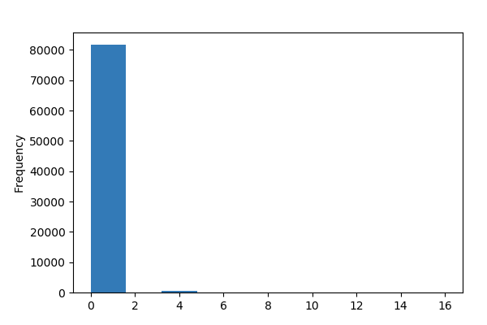

**Common Values**

| Value | Count | Frequency (%) |  |
| --- | --- | --- | --- |
| 0 | 74752 | 90.8% |  |
| 1 | 6908 | 8.4% |  |
| 4 | 478 | 0.6% |  |
| 9 | 126 | 0.2% |  |
| 16 | 32 | 0.0% |  |
| 2 | 18 | 0.0% |  |
| 12 | 12 | 0.0% |  |
| 6 | 6 | 0.0% |  |

**Extreme Values**

Minimum 5 values

| Value | Count | Frequency (%) |  |
| --- | --- | --- | --- |
| 0 | 74752 | 90.8% |  |
| 1 | 6908 | 8.4% |  |
| 2 | 18 | 0.0% |  |
| 4 | 478 | 0.6% |  |
| 6 | 6 | 0.0% |  |

Maximum 5 values

| Value | Count | Frequency (%) |  |
| --- | --- | --- | --- |
| 4 | 478 | 0.6% |  |
| 6 | 6 | 0.0% |  |
| 9 | 126 | 0.2% |  |
| 12 | 12 | 0.0% |  |
| 16 | 32 | 0.0% |  |

ct_ftp_cmd  
Highly correlated

*This variable is highly correlated with `is_ftp_login` and should be ignored for analysis*

| Correlation | 0.99434 |
| --- | --- |

ct_src_dport_ltm  
Highly correlated

*This variable is highly correlated with `ct_dst_ltm` and should be ignored for analysis*

| Correlation | 0.9604 |
| --- | --- |

ct_src_ltm  
Highly correlated

*This variable is highly correlated with `ct_src_dport_ltm` and should be ignored for analysis*

| Correlation | 0.93317 |
| --- | --- |

ct_srv_dst  
Highly correlated

*This variable is highly correlated with `ct_dst_src_ltm` and should be ignored for analysis*

| Correlation | 0.94105 |
| --- | --- |

ct_srv_src  
Numeric

| Distinct count | 57 |
| --- | --- |
| Unique (%) | 0.1% |
| Missing (%) | 0.0% |
| Missing (n) | 0 |
| Infinite (%) | 0.0% |
| Infinite (n) | 0 |

| Mean | 9.5466 |
| --- | --- |
| Minimum | 1 |
| Maximum | 63 |
| Zeros (%) | 0.0% |

Toggle details

**Statistics**

Quantile statistics

| Minimum | 1 |
| --- | --- |
| 5-th percentile | 1 |
| Q1 | 2 |
| Median | 5 |
| Q3 | 11 |
| 95-th percentile | 37 |
| Maximum | 63 |
| Range | 62 |
| Interquartile range | 9 |

Descriptive statistics

| Standard deviation | 11.09 |
| --- | --- |
| Coef of variation | 1.1617 |
| Kurtosis | 2.7575 |
| Mean | 9.5466 |
| MAD | 8.0389 |
| Skewness | 1.8564 |
| Sum | 785991 |
| Variance | 122.99 |
| Memory size | 643.3 KiB |

**Histogram**

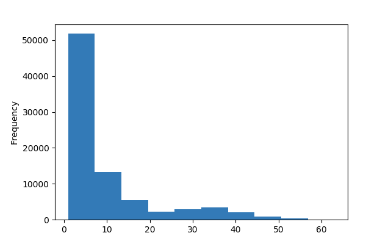

**Common Values**

| Value | Count | Frequency (%) |  |
| --- | --- | --- | --- |
| 1 | 13626 | 16.6% |  |
| 2 | 8986 | 10.9% |  |
| 3 | 7799 | 9.5% |  |
| 4 | 6583 | 8.0% |  |
| 5 | 5476 | 6.7% |  |
| 7 | 4897 | 5.9% |  |
| 6 | 4463 | 5.4% |  |
| 8 | 2877 | 3.5% |  |
| 10 | 2804 | 3.4% |  |
| 9 | 2638 | 3.2% |  |
| Other values (47) | 22183 | 26.9% |  |

**Extreme Values**

Minimum 5 values

| Value | Count | Frequency (%) |  |
| --- | --- | --- | --- |
| 1 | 13626 | 16.6% |  |
| 2 | 8986 | 10.9% |  |
| 3 | 7799 | 9.5% |  |
| 4 | 6583 | 8.0% |  |
| 5 | 5476 | 6.7% |  |

Maximum 5 values

| Value | Count | Frequency (%) |  |
| --- | --- | --- | --- |
| 53 | 26 | 0.0% |  |
| 54 | 27 | 0.0% |  |
| 58 | 25 | 0.0% |  |
| 59 | 30 | 0.0% |  |
| 63 | 2 | 0.0% |  |

ct_state_ttl  
Numeric

| Distinct count | 7 |
| --- | --- |
| Unique (%) | 0.0% |
| Missing (%) | 0.0% |
| Missing (n) | 0 |
| Infinite (%) | 0.0% |
| Infinite (n) | 0 |

| Mean | 1.3693 |
| --- | --- |
| Minimum | 0 |
| Maximum | 6 |
| Zeros (%) | 20.7% |

Toggle details

**Statistics**

Quantile statistics

| Minimum | 0 |
| --- | --- |
| 5-th percentile | 0 |
| Q1 | 1 |
| Median | 1 |
| Q3 | 2 |
| 95-th percentile | 2 |
| Maximum | 6 |
| Range | 6 |
| Interquartile range | 1 |

Descriptive statistics

| Standard deviation | 1.0672 |
| --- | --- |
| Coef of variation | 0.77938 |
| Kurtosis | 5.5394 |
| Mean | 1.3693 |
| MAD | 0.81125 |
| Skewness | 1.5222 |
| Sum | 112735 |
| Variance | 1.1389 |
| Memory size | 643.3 KiB |

**Histogram**

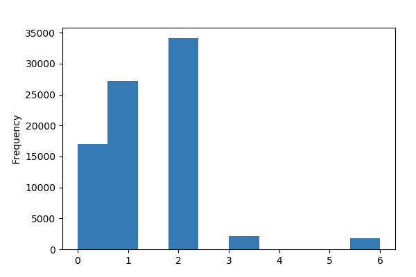

**Common Values**

| Value | Count | Frequency (%) |  |
| --- | --- | --- | --- |
| 2 | 34100 | 41.4% |  |
| 1 | 27234 | 33.1% |  |
| 0 | 17045 | 20.7% |  |
| 3 | 2120 | 2.6% |  |
| 6 | 1804 | 2.2% |  |
| 4 | 28 | 0.0% |  |
| 5 | 1 | 0.0% |  |

**Extreme Values**

Minimum 5 values

| Value | Count | Frequency (%) |  |
| --- | --- | --- | --- |
| 0 | 17045 | 20.7% |  |
| 1 | 27234 | 33.1% |  |
| 2 | 34100 | 41.4% |  |
| 3 | 2120 | 2.6% |  |
| 4 | 28 | 0.0% |  |

Maximum 5 values

| Value | Count | Frequency (%) |  |
| --- | --- | --- | --- |
| 2 | 34100 | 41.4% |  |
| 3 | 2120 | 2.6% |  |
| 4 | 28 | 0.0% |  |
| 5 | 1 | 0.0% |  |
| 6 | 1804 | 2.2% |  |

dbytes  
Highly correlated

*This variable is highly correlated with `dpkts` and should be ignored for analysis*

| Correlation | 0.97642 |
| --- | --- |

dinpkt  
Numeric

| Distinct count | 37617 |
| --- | --- |
| Unique (%) | 45.7% |
| Missing (%) | 0.0% |
| Missing (n) | 0 |
| Infinite (%) | 0.0% |
| Infinite (n) | 0 |

| Mean | 121.7 |
| --- | --- |
| Minimum | 0 |
| Maximum | 57739 |
| Zeros (%) | 43.7% |

Toggle details

**Statistics**

Quantile statistics

| Minimum | 0 |
| --- | --- |
| 5-th percentile | 0 |
| Q1 | 0 |
| Median | 0.01 |
| Q3 | 63.136 |
| 95-th percentile | 167.63 |
| Maximum | 57739 |
| Range | 57739 |
| Interquartile range | 63.136 |

Descriptive statistics

| Standard deviation | 1292.4 |
| --- | --- |
| Coef of variation | 10.619 |
| Kurtosis | 669.68 |
| Mean | 121.7 |
| MAD | 182 |
| Skewness | 23.013 |
| Sum | 10020000 |
| Variance | 1670200 |
| Memory size | 643.3 KiB |

**Histogram**

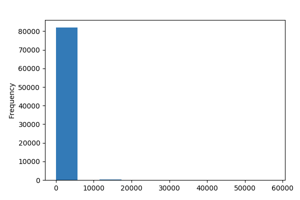

**Common Values**

| Value | Count | Frequency (%) |  |
| --- | --- | --- | --- |
| 0.0 | 36015 | 43.7% |  |
| 0.008 | 1331 | 1.6% |  |
| 0.009000000000000001 | 904 | 1.1% |  |
| 0.006999999999999999 | 641 | 0.8% |  |
| 0.002 | 508 | 0.6% |  |
| 0.006 | 427 | 0.5% |  |
| 0.003 | 387 | 0.5% |  |
| 0.005 | 311 | 0.4% |  |
| 0.004 | 265 | 0.3% |  |
| 0.001 | 248 | 0.3% |  |
| Other values (37607) | 41295 | 50.2% |  |

**Extreme Values**

Minimum 5 values

| Value | Count | Frequency (%) |  |
| --- | --- | --- | --- |
| 0.0 | 36015 | 43.7% |  |
| 0.001 | 248 | 0.3% |  |
| 0.002 | 508 | 0.6% |  |
| 0.003 | 387 | 0.5% |  |
| 0.004 | 265 | 0.3% |  |

Maximum 5 values

| Value | Count | Frequency (%) |  |
| --- | --- | --- | --- |
| 46819.568 | 2 | 0.0% |  |
| 46928.632000000005 | 2 | 0.0% |  |
| 48857.6 | 3 | 0.0% |  |
| 49369.404 | 2 | 0.0% |  |
| 57739.24 | 2 | 0.0% |  |

djit  
Numeric

| Distinct count | 38381 |
| --- | --- |
| Unique (%) | 46.6% |
| Missing (%) | 0.0% |
| Missing (n) | 0 |
| Infinite (%) | 0.0% |
| Infinite (n) | 0 |

| Mean | 535.18 |
| --- | --- |
| Minimum | 0 |
| Maximum | 463200 |
| Zeros (%) | 50.5% |

Toggle details

**Statistics**

Quantile statistics

| Minimum | 0 |
| --- | --- |
| 5-th percentile | 0 |
| Q1 | 0 |
| Median | 0 |
| Q3 | 128.46 |
| 95-th percentile | 2218.9 |
| Maximum | 463200 |
| Range | 463200 |
| Interquartile range | 128.46 |

Descriptive statistics

| Standard deviation | 3635.3 |
| --- | --- |
| Coef of variation | 6.7927 |
| Kurtosis | 6850.3 |
| Mean | 535.18 |
| MAD | 882.25 |
| Skewness | 60.562 |
| Sum | 44062000 |
| Variance | 13215000 |
| Memory size | 643.3 KiB |

**Histogram**

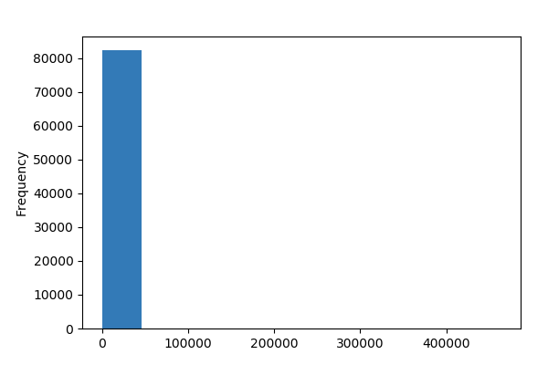

**Common Values**

| Value | Count | Frequency (%) |  |
| --- | --- | --- | --- |
| 0.0 | 41552 | 50.5% |  |
| 196.928172 | 20 | 0.0% |  |
| 70.142297 | 11 | 0.0% |  |
| 12723.928 | 9 | 0.0% |  |
| 7579.063 | 9 | 0.0% |  |
| 8904.09 | 8 | 0.0% |  |
| 31316.11 | 8 | 0.0% |  |
| 14514.05 | 8 | 0.0% |  |
| 178.020453 | 6 | 0.0% |  |
| 178.32976599999998 | 6 | 0.0% |  |
| Other values (38371) | 40695 | 49.4% |  |

**Extreme Values**

Minimum 5 values

| Value | Count | Frequency (%) |  |
| --- | --- | --- | --- |
| 0.0 | 41552 | 50.5% |  |
| 0.189686 | 1 | 0.0% |  |
| 0.193996 | 1 | 0.0% |  |
| 0.199525 | 1 | 0.0% |  |
| 0.223681 | 1 | 0.0% |  |

Maximum 5 values

| Value | Count | Frequency (%) |  |
| --- | --- | --- | --- |
| 57739.232 | 2 | 0.0% |  |
| 80453.74535 | 1 | 0.0% |  |
| 106494.4286 | 1 | 0.0% |  |
| 237306.8633 | 2 | 0.0% |  |
| 463199.2401 | 2 | 0.0% |  |

dload  
Numeric

| Distinct count | 40614 |
| --- | --- |
| Unique (%) | 49.3% |
| Missing (%) | 0.0% |
| Missing (n) | 0 |
| Infinite (%) | 0.0% |
| Infinite (n) | 0 |

| Mean | 630550 |
| --- | --- |
| Minimum | 0 |
| Maximum | 20821000 |
| Zeros (%) | 43.7% |

Toggle details

**Statistics**

Quantile statistics

| Minimum | 0 |
| --- | --- |
| 5-th percentile | 0 |
| Q1 | 0 |
| Median | 2113 |
| Q3 | 15858 |
| 95-th percentile | 3741400 |
| Maximum | 20821000 |
| Range | 20821000 |
| Interquartile range | 15858 |

Descriptive statistics

| Standard deviation | 2393000 |
| --- | --- |
| Coef of variation | 3.7951 |
| Kurtosis | 22.751 |
| Mean | 630550 |
| MAD | 1048900 |
| Skewness | 4.7539 |
| Sum | 51914000000 |
| Variance | 5726500000000 |
| Memory size | 643.3 KiB |

**Histogram**

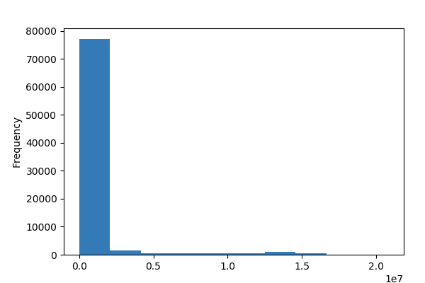

**Common Values**

| Value | Count | Frequency (%) |  |
| --- | --- | --- | --- |
| 0.0 | 36013 | 43.7% |  |
| 657433.0625 | 27 | 0.0% |  |
| 678741.6875 | 25 | 0.0% |  |
| 676806.125 | 24 | 0.0% |  |
| 664799.25 | 24 | 0.0% |  |
| 668544.625 | 23 | 0.0% |  |
| 662942.25 | 22 | 0.0% |  |
| 693957.125 | 22 | 0.0% |  |
| 664179.125 | 21 | 0.0% |  |
| 662325.5625 | 21 | 0.0% |  |
| Other values (40604) | 46110 | 56.0% |  |

**Extreme Values**

Minimum 5 values

| Value | Count | Frequency (%) |  |
| --- | --- | --- | --- |
| 0.0 | 36013 | 43.7% |  |
| 5.813612 | 2 | 0.0% |  |
| 7.453856 | 2 | 0.0% |  |
| 8.287422 | 2 | 0.0% |  |
| 9.244214999999999 | 2 | 0.0% |  |

Maximum 5 values

| Value | Count | Frequency (%) |  |
| --- | --- | --- | --- |
| 19633496.0 | 1 | 0.0% |  |
| 19705236.0 | 1 | 0.0% |  |
| 20103138.0 | 1 | 0.0% |  |
| 20232470.0 | 1 | 0.0% |  |
| 20821108.0 | 1 | 0.0% |  |

dloss  
Highly correlated

*This variable is highly correlated with `dbytes` and should be ignored for analysis*

| Correlation | 0.99711 |
| --- | --- |

dmean  
Numeric

| Distinct count | 1222 |
| --- | --- |
| Unique (%) | 1.5% |
| Missing (%) | 0.0% |
| Missing (n) | 0 |
| Infinite (%) | 0.0% |
| Infinite (n) | 0 |

| Mean | 116.28 |
| --- | --- |
| Minimum | 0 |
| Maximum | 1500 |
| Zeros (%) | 43.7% |

Toggle details

**Statistics**

Quantile statistics

| Minimum | 0 |
| --- | --- |
| 5-th percentile | 0 |
| Q1 | 0 |
| Median | 44 |
| Q3 | 87 |
| 95-th percentile | 683 |
| Maximum | 1500 |
| Range | 1500 |
| Interquartile range | 87 |

Descriptive statistics

| Standard deviation | 244.6 |
| --- | --- |
| Coef of variation | 2.1036 |
| Kurtosis | 9.6855 |
| Mean | 116.28 |
| MAD | 143.86 |
| Skewness | 3.1068 |
| Sum | 9573159 |
| Variance | 59829 |
| Memory size | 643.3 KiB |

**Histogram**

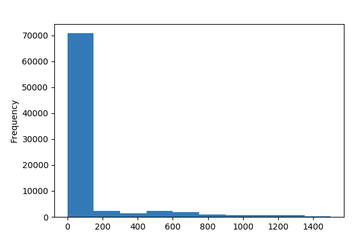

**Common Values**

| Value | Count | Frequency (%) |  |
| --- | --- | --- | --- |
| 0 | 36006 | 43.7% |  |
| 45 | 7243 | 8.8% |  |
| 44 | 6283 | 7.6% |  |
| 89 | 2260 | 2.7% |  |
| 43 | 2143 | 2.6% |  |
| 91 | 1790 | 2.2% |  |
| 565 | 1194 | 1.5% |  |
| 76 | 1079 | 1.3% |  |
| 82 | 1077 | 1.3% |  |
| 57 | 919 | 1.1% |  |
| Other values (1212) | 22338 | 27.1% |  |

**Extreme Values**

Minimum 5 values

| Value | Count | Frequency (%) |  |
| --- | --- | --- | --- |
| 0 | 36006 | 43.7% |  |
| 28 | 28 | 0.0% |  |
| 39 | 2 | 0.0% |  |
| 41 | 21 | 0.0% |  |
| 43 | 2143 | 2.6% |  |

Maximum 5 values

| Value | Count | Frequency (%) |  |
| --- | --- | --- | --- |
| 1464 | 1 | 0.0% |  |
| 1469 | 1 | 0.0% |  |
| 1470 | 1 | 0.0% |  |
| 1471 | 1 | 0.0% |  |
| 1500 | 1 | 0.0% |  |

dpkts  
Numeric

| Distinct count | 436 |
| --- | --- |
| Unique (%) | 0.5% |
| Missing (%) | 0.0% |
| Missing (n) | 0 |
| Infinite (%) | 0.0% |
| Infinite (n) | 0 |

| Mean | 17.546 |
| --- | --- |
| Minimum | 0 |
| Maximum | 11018 |
| Zeros (%) | 43.7% |

Toggle details

**Statistics**

Quantile statistics

| Minimum | 0 |
| --- | --- |
| 5-th percentile | 0 |
| Q1 | 0 |
| Median | 2 |
| Q3 | 10 |
| 95-th percentile | 54 |
| Maximum | 11018 |
| Range | 11018 |
| Interquartile range | 10 |

Descriptive statistics

| Standard deviation | 115.57 |
| --- | --- |
| Coef of variation | 6.5869 |
| Kurtosis | 3833.6 |
| Mean | 17.546 |
| MAD | 23.294 |
| Skewness | 49.304 |
| Sum | 1444592 |
| Variance | 13357 |
| Memory size | 643.3 KiB |

**Histogram**

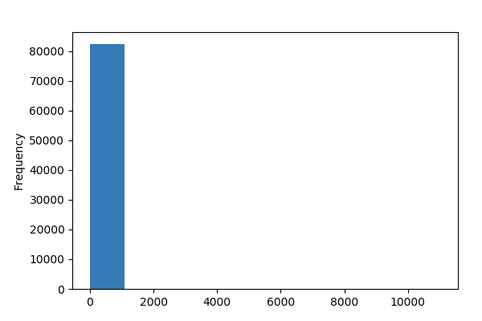

**Common Values**

| Value | Count | Frequency (%) |  |
| --- | --- | --- | --- |
| 0 | 36006 | 43.7% |  |
| 8 | 9465 | 11.5% |  |
| 6 | 7464 | 9.1% |  |
| 2 | 5448 | 6.6% |  |
| 10 | 3746 | 4.5% |  |
| 18 | 3362 | 4.1% |  |
| 12 | 2217 | 2.7% |  |
| 4 | 1411 | 1.7% |  |
| 14 | 1408 | 1.7% |  |
| 20 | 1022 | 1.2% |  |
| Other values (426) | 10783 | 13.1% |  |

**Extreme Values**

Minimum 5 values

| Value | Count | Frequency (%) |  |
| --- | --- | --- | --- |
| 0 | 36006 | 43.7% |  |
| 1 | 7 | 0.0% |  |
| 2 | 5448 | 6.6% |  |
| 3 | 15 | 0.0% |  |
| 4 | 1411 | 1.7% |  |

Maximum 5 values

| Value | Count | Frequency (%) |  |
| --- | --- | --- | --- |
| 7728 | 1 | 0.0% |  |
| 7958 | 1 | 0.0% |  |
| 10872 | 1 | 0.0% |  |
| 10970 | 1 | 0.0% |  |
| 11018 | 1 | 0.0% |  |

dtcpb  
Numeric

| Distinct count | 39108 |
| --- | --- |
| Unique (%) | 47.5% |
| Missing (%) | 0.0% |
| Missing (n) | 0 |
| Infinite (%) | 0.0% |
| Infinite (n) | 0 |

| Mean | 1073500000 |
| --- | --- |
| Minimum | 0 |
| Maximum | 4294880717 |
| Zeros (%) | 49.7% |

Toggle details

**Statistics**

Quantile statistics

| Minimum | 0 |
| --- | --- |
| 5-th percentile | 0 |
| Q1 | 0 |
| Median | 28570000 |
| Q3 | 2144200000 |
| 95-th percentile | 3862500000 |
| Maximum | 4294880717 |
| Range | 4294880717 |
| Interquartile range | 2144200000 |

Descriptive statistics

| Standard deviation | 1382000000 |
| --- | --- |
| Coef of variation | 1.2874 |
| Kurtosis | -0.61524 |
| Mean | 1073500000 |
| MAD | 1203400000 |
| Skewness | 0.93014 |
| Sum | 88380493282924 |
| Variance | 1.9099e+18 |
| Memory size | 643.3 KiB |

**Histogram**

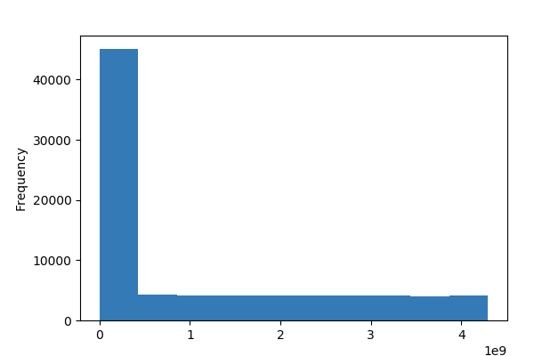

**Common Values**

| Value | Count | Frequency (%) |  |
| --- | --- | --- | --- |
| 0 | 40894 | 49.7% |  |
| 1460955064 | 24 | 0.0% |  |
| 3773804157 | 18 | 0.0% |  |
| 463094449 | 12 | 0.0% |  |
| 3359643724 | 9 | 0.0% |  |
| 1566633851 | 9 | 0.0% |  |
| 3359643916 | 9 | 0.0% |  |
| 1649858926 | 9 | 0.0% |  |
| 4014127149 | 9 | 0.0% |  |
| 622235735 | 9 | 0.0% |  |
| Other values (39098) | 41330 | 50.2% |  |

**Extreme Values**

Minimum 5 values

| Value | Count | Frequency (%) |  |
| --- | --- | --- | --- |
| 0 | 40894 | 49.7% |  |
| 62765 | 1 | 0.0% |  |
| 278275 | 1 | 0.0% |  |
| 285397 | 1 | 0.0% |  |
| 388531 | 1 | 0.0% |  |

Maximum 5 values

| Value | Count | Frequency (%) |  |
| --- | --- | --- | --- |
| 4293838832 | 1 | 0.0% |  |
| 4293860065 | 1 | 0.0% |  |
| 4294324529 | 1 | 0.0% |  |
| 4294690570 | 1 | 0.0% |  |
| 4294880717 | 1 | 0.0% |  |

dttl  
Numeric

| Distinct count | 8 |
| --- | --- |
| Unique (%) | 0.0% |
| Missing (%) | 0.0% |
| Missing (n) | 0 |
| Infinite (%) | 0.0% |
| Infinite (n) | 0 |

| Mean | 95.713 |
| --- | --- |
| Minimum | 0 |
| Maximum | 253 |
| Zeros (%) | 43.8% |

Toggle details

**Statistics**

Quantile statistics

| Minimum | 0 |
| --- | --- |
| 5-th percentile | 0 |
| Q1 | 0 |
| Median | 29 |
| Q3 | 252 |
| 95-th percentile | 252 |
| Maximum | 253 |
| Range | 253 |
| Interquartile range | 252 |

Descriptive statistics

| Standard deviation | 116.67 |
| --- | --- |
| Coef of variation | 1.2189 |
| Kurtosis | -1.6342 |
| Mean | 95.713 |
| MAD | 111.2 |
| Skewness | 0.57521 |
| Sum | 7880243 |
| Variance | 13611 |
| Memory size | 643.3 KiB |

**Histogram**

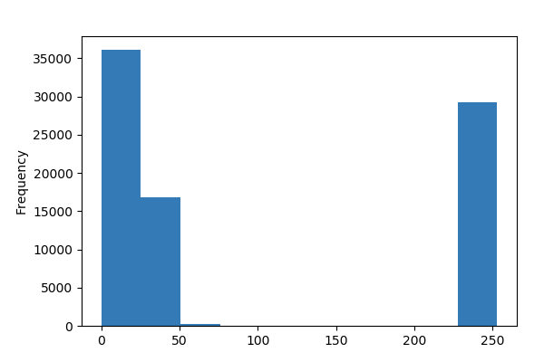

**Common Values**

| Value | Count | Frequency (%) |  |
| --- | --- | --- | --- |
| 0 | 36067 | 43.8% |  |
| 252 | 29280 | 35.6% |  |
| 29 | 16668 | 20.2% |  |
| 60 | 225 | 0.3% |  |
| 30 | 43 | 0.1% |  |
| 31 | 36 | 0.0% |  |
| 253 | 9 | 0.0% |  |
| 32 | 4 | 0.0% |  |

**Extreme Values**

Minimum 5 values

| Value | Count | Frequency (%) |  |
| --- | --- | --- | --- |
| 0 | 36067 | 43.8% |  |
| 29 | 16668 | 20.2% |  |
| 30 | 43 | 0.1% |  |
| 31 | 36 | 0.0% |  |
| 32 | 4 | 0.0% |  |

Maximum 5 values

| Value | Count | Frequency (%) |  |
| --- | --- | --- | --- |
| 31 | 36 | 0.0% |  |
| 32 | 4 | 0.0% |  |
| 60 | 225 | 0.3% |  |
| 252 | 29280 | 35.6% |  |
| 253 | 9 | 0.0% |  |

dur  
Numeric

| Distinct count | 39888 |
| --- | --- |
| Unique (%) | 48.4% |
| Missing (%) | 0.0% |
| Missing (n) | 0 |
| Infinite (%) | 0.0% |
| Infinite (n) | 0 |

| Mean | 1.0068 |
| --- | --- |
| Minimum | 0 |
| Maximum | 60 |
| Zeros (%) | 1.2% |

Toggle details

**Statistics**

Quantile statistics

| Minimum | 0 |
| --- | --- |
| 5-th percentile | 3e-06 |
| Q1 | 8e-06 |
| Median | 0.014138 |
| Q3 | 0.71936 |
| 95-th percentile | 2.4038 |
| Maximum | 60 |
| Range | 60 |
| Interquartile range | 0.71935 |

Descriptive statistics

| Standard deviation | 4.7104 |
| --- | --- |
| Coef of variation | 4.6788 |
| Kurtosis | 100.29 |
| Mean | 1.0068 |
| MAD | 1.3635 |
| Skewness | 9.5238 |
| Sum | 82888 |
| Variance | 22.188 |
| Memory size | 643.3 KiB |

**Histogram**

[17 more figures not shown]

Sample

|  | id | dur | proto | service | state | spkts | dpkts | sbytes | dbytes | rate | sttl | dttl | sload | dload | sloss | dloss | sinpkt | dinpkt | sjit | djit | swin | stcpb | dtcpb | dwin | tcprtt | synack | ackdat | smean | dmean | … |
| --- | --- | --- | --- | --- | --- | --- | --- | --- | --- | --- | --- | --- | --- | --- | --- | --- | --- | --- | --- | --- | --- | --- | --- | --- | --- | --- | --- | --- | --- | --- |
| 0 | 1 | 0.000011 | udp | - | INT | 2 | 0 | 496 | 0 | 90909.0902 | 254 | 0 | 180363632.0 | 0.0 | 0 | 0 | 0.011 | 0.0 | 0.0 | 0.0 | 0 | 0 | 0 | 0 | 0.0 | 0.0 | 0.0 | 248 | 0 | … |
| 1 | 2 | 0.000008 | udp | - | INT | 2 | 0 | 1762 | 0 | 125000.0003 | 254 | 0 | 881000000.0 | 0.0 | 0 | 0 | 0.008 | 0.0 | 0.0 | 0.0 | 0 | 0 | 0 | 0 | 0.0 | 0.0 | 0.0 | 881 | 0 | … |
| 2 | 3 | 0.000005 | udp | - | INT | 2 | 0 | 1068 | 0 | 200000.0051 | 254 | 0 | 854400000.0 | 0.0 | 0 | 0 | 0.005 | 0.0 | 0.0 | 0.0 | 0 | 0 | 0 | 0 | 0.0 | 0.0 | 0.0 | 534 | 0 | … |
| 3 | 4 | 0.000006 | udp | - | INT | 2 | 0 | 900 | 0 | 166666.6608 | 254 | 0 | 600000000.0 | 0.0 | 0 | 0 | 0.006 | 0.0 | 0.0 | 0.0 | 0 | 0 | 0 | 0 | 0.0 | 0.0 | 0.0 | 450 | 0 | … |
| 4 | 5 | 0.000010 | udp | - | INT | 2 | 0 | 2126 | 0 | 100000.0025 | 254 | 0 | 850400000.0 | 0.0 | 0 | 0 | 0.010 | 0.0 | 0.0 | 0.0 | 0 | 0 | 0 | 0 | 0.0 | 0.0 | 0.0 | 1063 | 0 | … |

```python
pandas_report = pandas_profiling.ProfileReport(dataframe_training)
pandas_report
```

```python
rejected_variables_list = pandas_report.get_rejected_variables()
print(rejected_variables_list)
```

```
['ct_dst_sport_ltm', 'ct_dst_src_ltm', 'ct_ftp_cmd', 'ct_src_dport_ltm', 'ct_src_ltm', 'ct_srv_dst', 'dbytes', 'dloss', 'dwin', 'is_sm_ips_ports', 'sbytes', 'sloss', 'synack']
```

No se encuentran datos vacíos, ni se evidencian valores constantes que no aporten al dataset. Sin embargo, si se observan correlaciones entre los datos que pueden usarse más adelante para elaborar una hipótesis

**4) Exploración de los datos**

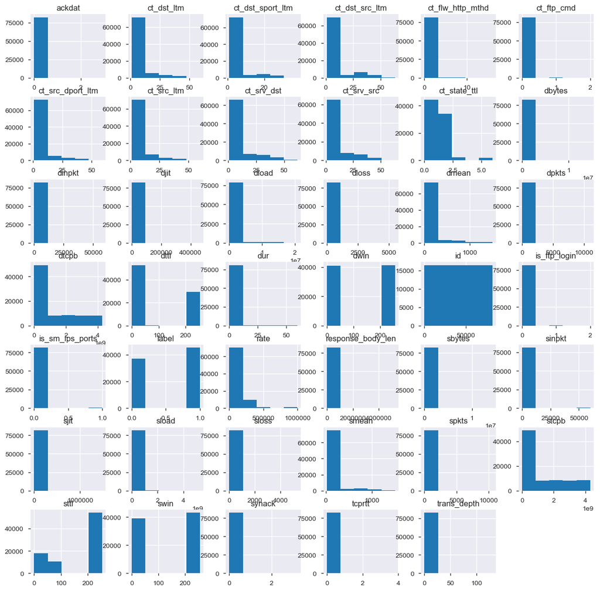

```python
dataframe_training.hist(bins=5, figsize=(15,15));
```

Graficamos el conteo del tipo de ataque respecto a la etiqueta:

"attact_cat" -vs- label

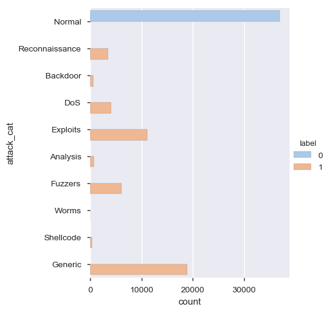

```python
df_attack_label = dataframe_training[["attack_cat","label"]].copy()
df_attack_label["label"] = df_attack_label["label"].apply(lambda x: str(x))
sns.catplot(y="attack_cat", hue="label", kind="count",palette="pastel", edgecolor=".6",data=df_attack_label);
```

**Datos de entrenamiento**

La variable **"attack_cat"** se encuentra correlacionada con la etiqueta de ataques, esto quiere decir que la variable **"label"** es una generalización o agrupación de las categorias encontradas en la variable **"attack_cat"**.

Sabiendo **"attack_cat"** es un variable completamente asociada a la descrición de los ataques definida por expertos y en la necesidad de construir un detector de eventos maliciosos se precisa contemplar unicamente las variables disponibles durante la puesta en marcha del estimador de eventos, las cuales estan relacionadas unicamente a los protocolos de comunicación, por tal motivo se descarta la variable **"attack_cat"**.

- Quitamos la columna ID ya que no aporta información
- Quitamos la variable attack_cat

```python
# Creamos un escalador comun para los datos
standard_scaler = StandardScaler()
```

```python
# Dividimos la clase del dataframe
dataframe_training_x = dataframe_training[['dur', 'proto', 'service', 'state', 'spkts', 'dpkts', 'sbytes',
       'dbytes', 'rate', 'sttl', 'dttl', 'sload', 'dload', 'sloss', 'dloss',
       'sinpkt', 'dinpkt', 'sjit', 'djit', 'swin', 'stcpb', 'dtcpb', 'dwin',
       'tcprtt', 'synack', 'ackdat', 'smean', 'dmean', 'trans_depth',
       'response_body_len', 'ct_srv_src', 'ct_state_ttl', 'ct_dst_ltm',
       'ct_src_dport_ltm', 'ct_dst_sport_ltm', 'ct_dst_src_ltm',
       'is_ftp_login', 'ct_ftp_cmd', 'ct_flw_http_mthd', 'ct_src_ltm',
       'ct_srv_dst', 'is_sm_ips_ports']]
dataframe_training_y = dataframe_training[['label']]

dataframe_training_x_no_cat = pd.get_dummies(dataframe_training_x)

# Estos datos están presentes en testing pero no en entrenamiento, luego los agregamos por defecto
training_columns = dataframe_training_x_no_cat.columns.values

# Escalamos el set de datos para mejorar el funcionamiento del algoritmo
dataframe_training_x_scaled = standard_scaler.fit_transform(dataframe_training_x_no_cat)

X_train = dataframe_training_x_scaled
y_train = dataframe_training_y

print (X_train.shape, y_train.shape)
```

```
(82332, 190) (82332, 1)
```

**Datos de prueba**

El mismo tratamiento con los datos realizados con el entrenamiento, lo hacemos con los datos de prueba. Es importante anotar que al obtener los dummies no se obtienen las mismas columnas que los datos de training. Por lo tanto, se descartan las columnas adicionales de los datos de testing y prevalece el tratamiento aplicado a los datos de entrenamiento.

Las siguientes columnas están en entrenamiento, pero no en testing, por lo que se agregan al dataframe

- state_ACC
- state_CLO

```python
# Dividimos la clase del dataframe
dataframe_testing_x = dataframe_testing[['dur', 'proto', 'service', 'state', 'spkts', 'dpkts', 'sbytes',
       'dbytes', 'rate', 'sttl', 'dttl', 'sload', 'dload', 'sloss', 'dloss',
       'sinpkt', 'dinpkt', 'sjit', 'djit', 'swin', 'stcpb', 'dtcpb', 'dwin',
       'tcprtt', 'synack', 'ackdat', 'smean', 'dmean', 'trans_depth',
       'response_body_len', 'ct_srv_src', 'ct_state_ttl', 'ct_dst_ltm',
       'ct_src_dport_ltm', 'ct_dst_sport_ltm', 'ct_dst_src_ltm',
       'is_ftp_login', 'ct_ftp_cmd', 'ct_flw_http_mthd', 'ct_src_ltm',
       'ct_srv_dst', 'is_sm_ips_ports']]
dataframe_testing_y = dataframe_testing[['label']]

dataframe_testing_x_no_cat = pd.get_dummies(dataframe_testing_x)

dataframe_testing_x_no_cat['state_ACC'] = 0
dataframe_testing_x_no_cat['state_CLO'] = 0

dataframe_testing_x_no_cat_same_columns = dataframe_testing_x_no_cat[training_columns].copy()

# Escalamos el set de datos para mejorar el funcionamiento del algoritmo
dataframe_testing_x_scaled = standard_scaler.fit_transform(dataframe_testing_x_no_cat_same_columns)

X_test = dataframe_testing_x_scaled
y_test = dataframe_testing_y

print (X_test.shape, y_test.shape)
```

```
(175341, 190) (175341, 1)
```

**Entrenamiento del modelo**

```python
# Se crea el modelo de regresión lineal
model = LogisticRegression(solver="lbfgs")
model.fit(X_train, y_train)

print('Precision del Modelo de Regresión Lineal en entrenamiento: {:.2f}'.format(model.score(X_train, y_train)))
```

```
Precision del Modelo de Regresión Lineal en entrenamiento: 0.92
```

```python
y_pred = model.predict(X_test)
print('Precision del Modelo de Regresión Lineal en entrenamiento: {:.2f}'.format(model.score(X_test, y_test)))
```

```
Precision del Modelo de Regresión Lineal en entrenamiento: 0.90
```

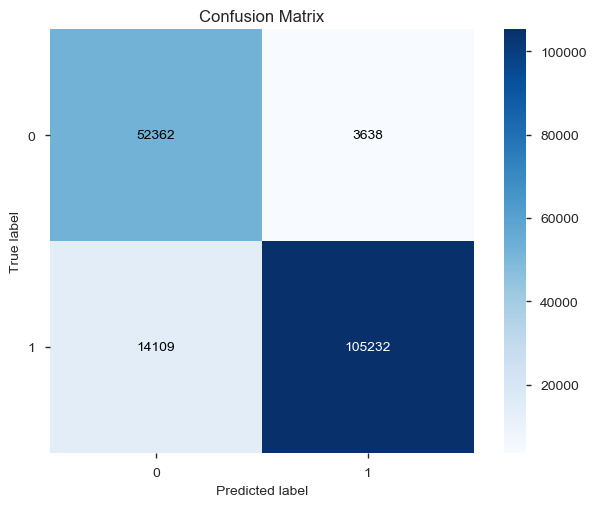

```python
# Obtenemos la matriz de confusión
skplt.metrics.plot_confusion_matrix(y_test, y_pred)
plt.show()
```

```python
print(metrics.classification_report(y_test, y_pred, labels=[0,1]))
```

```
              precision    recall  f1-score   support

           0       0.79      0.94      0.86     56000
           1       0.97      0.88      0.92    119341

   micro avg       0.90      0.90      0.90    175341
   macro avg       0.88      0.91      0.89    175341
weighted avg       0.91      0.90      0.90    175341
```

**Entonamos el modelo**

Utilizamos Grid Search para mejorar la precisión del modelo

```python
grid = {"solver": ["lbfgs", "sag"], "C": np.logspace(-3,3,7), "penalty":["l2"]}
```

```python
model_cv = LogisticRegression(max_iter=300)
grid_search_cv = GridSearchCV(model_cv, grid, cv=20, n_jobs=-1)
grid_search_cv.fit(X_train, y_train['label'])
```

```
GridSearchCV(cv=20, error_score='raise-deprecating',
       estimator=LogisticRegression(C=1.0, class_weight=None, dual=False, fit_intercept=True,
          intercept_scaling=1, max_iter=300, multi_class='warn',
          n_jobs=None, penalty='l2', random_state=None, solver='warn',
          tol=0.0001, verbose=0, warm_start=False),
       fit_params=None, iid='warn', n_jobs=-1,
       param_grid={'solver': ['lbfgs', 'sag'], 'C': array([1.e-03, 1.e-02, 1.e-01, 1.e+00, 1.e+01, 1.e+02, 1.e+03]), 'penalty': ['l2']},
       pre_dispatch='2*n_jobs', refit=True, return_train_score='warn',
       scoring=None, verbose=0)
```

```python
print("Accuracy :", grid_search_cv.best_score_)
```

```
Accuracy : 0.9164116018073167
```

```python
print("Mejores parámetros :", grid_search_cv.best_params_ )
```

```
Mejores parámetros : {'C': 1000.0, 'penalty': 'l2', 'solver': 'lbfgs'}
```

**Entrenamos el modelo con los mejores parametros**

```python
# Se crea el modelo de regresión lineal
best_model = LogisticRegression(C=1000, solver="lbfgs", max_iter=300)
best_model.fit(X_train, y_train)
```

```
LogisticRegression(C=1000, class_weight=None, dual=False, fit_intercept=True,
          intercept_scaling=1, max_iter=300, multi_class='warn',
          n_jobs=None, penalty='l2', random_state=None, solver='lbfgs',
          tol=0.0001, verbose=0, warm_start=False)
```

```python
y_best_pred = best_model.predict(X_test)
print('Precision del Modelo de Regresión Lineal en entrenamiento: {:.2f}'.format(best_model.score(X_test, y_test)))
```

```
Precision del Modelo de Regresión Lineal en entrenamiento: 0.91
```

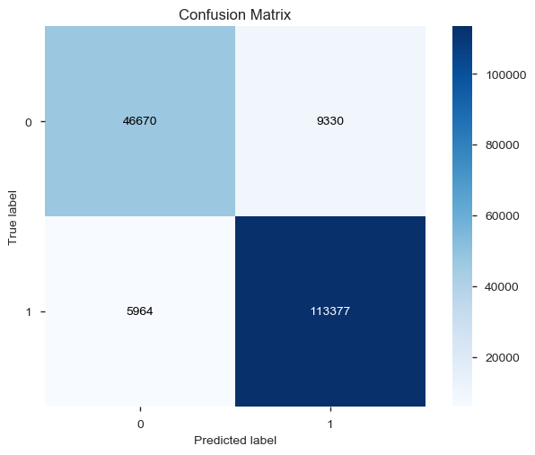

```python
# Obtenemos la matriz de confusión
skplt.metrics.plot_confusion_matrix(y_test, y_best_pred)
plt.show()
```

```python
print(metrics.classification_report(y_test, y_best_pred, labels=[0,1]))
```

```
              precision    recall  f1-score   support

           0       0.89      0.83      0.86     56000
           1       0.92      0.95      0.94    119341

   micro avg       0.91      0.91      0.91    175341
   macro avg       0.91      0.89      0.90    175341
weighted avg       0.91      0.91      0.91    175341
```

**Experimento:**

Visualizamos la información por medio de PCA

```python
pca = PCA(n_components=2)
pca_comps = pca.fit_transform(X_train)
pca_df_x = pd.DataFrame(data = pca_comps, columns = ['comp1', 'comp2'])
pca_df = pd.concat([pca_df_x, y_train[['label']]], axis = 1)
```

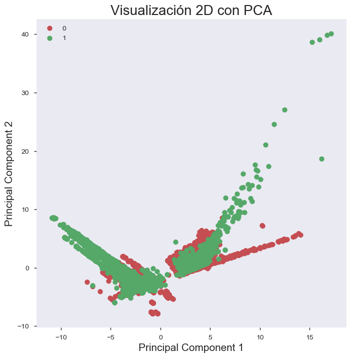

```python
fig = plt.figure(figsize = (8,8))
ax = fig.add_subplot(1,1,1)
ax.set_xlabel('Principal Component 1', fontsize = 15)
ax.set_ylabel('Principal Component 2', fontsize = 15)
ax.set_title('Visualización 2D con PCA', fontsize = 20)
targets = [0, 1]
colors = ['r', 'g']
for target, color in zip(targets,colors):
    indicesToKeep = pca_df['label'] == target
    ax.scatter(pca_df.loc[indicesToKeep, 'comp1']
               , pca_df.loc[indicesToKeep, 'comp2']
               , c = color
               , s = 50)
ax.legend(targets)
ax.grid()
```

**Conclusiones:**

- Es fundamental conocer e interpretar adecuadamente los datos para obtener buenos resultados.
- El algoritmo de regresión logística presentó muy buenos resultados para la resolución de este problema. Sin embargo, de acuerdo al Grid Search con 300 iteraciones aún no converge
- Se logró entonar el algoritmo con una precisión de 91%
- El tiempo de procesamiento para hallar los mejores valores requiere una buena capacidad de cómputo.